# JSC370 Final Project

Impact of Weather on TTC Subway Delays

Xiran Yin

# Research Focus

## Question

How strongly do adverse weather conditions explain day-level TTC subway delay burden in Toronto?

## Goals

- Build a reproducible API-based dataset (2014-2026)
- Compare regression and classification models
- Identify top weather predictors of severe-delay days
- Deliver interactive results for exploration

# Data and Pipeline

- **Weather API:** Open-Meteo daily archive
- **Transit API:** Toronto Open Data CKAN (`ttc-subway-delay-data`)
- Multi-file TTC ingestion with robust column harmonization
- Daily-level merge and engineered weather features
- Reproducible pipeline: `scripts/final_pipeline.py`

# Core Features

- Precipitation (`precip_mm`)
- Snowfall (`snowfall_cm`)
- Wind gust speed (`gust_speed`)
- Mean temperature (`mean_temp_c`)
- Precipitation intensity (`precip_intensity`)
- Weekend indicator and month seasonality

**Classification target:** Severe-delay day = top 25% of daily delay totals.

# Descriptive Signal

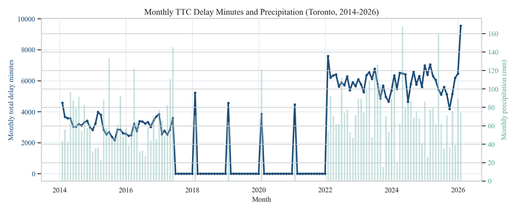

# Weather Severity Effect

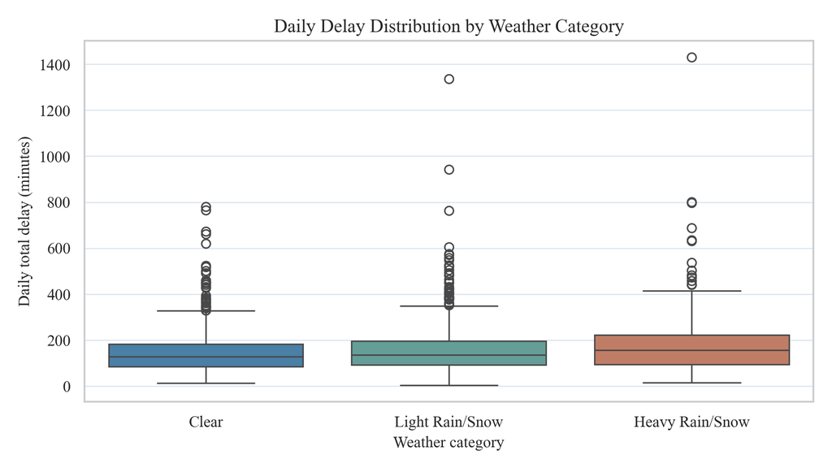

Heavy rain/snow days show higher median delay and wider extreme tail.

# Modeling Results

## Regression

- Baseline: Linear Regression
- Main model: Random Forest Regressor

## Classification

- Baseline: Logistic Regression
- Main model: Random Forest Classifier

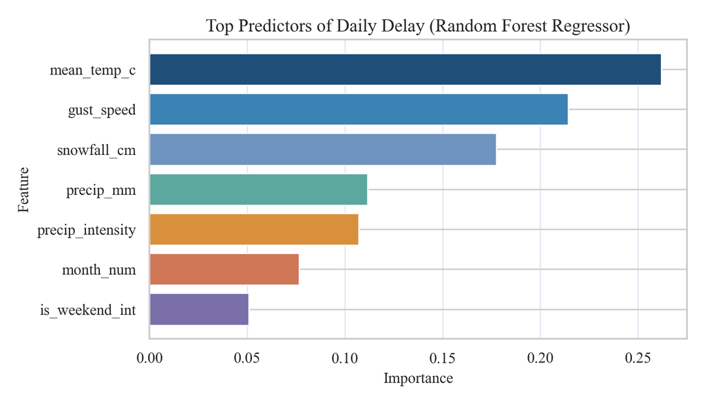